[figure not shown]

# WERATEDOGS ACTS REPORT

### by Dedenuola Oluwashina

#### Being part of the requirement for for the fulfilment of my Udacity Nanodegree Program

The aim of this report is to express the visualization part of this project as well as provide valuable insights.

**The visualization aspect of the weratedogs involves visualizing to report:**

Tweet engagements from Weratedogs as it relates to the Dog Stages

Tweet engagements from Weratedogs as it relates to the Dog Names and,

Tweet engagements from Weratedogs as it relates to the Dog Breed.

**Dog Stages Tweet Engagement**

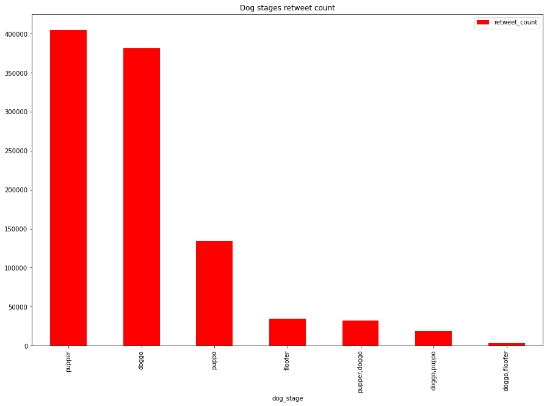

I was able to establish some interesting facts as it relates to the dog stages with the most counts in terms of tweets favourite with the pupper dog stage having the highest favourite count followed by doggo, puppo and floofer respectively.

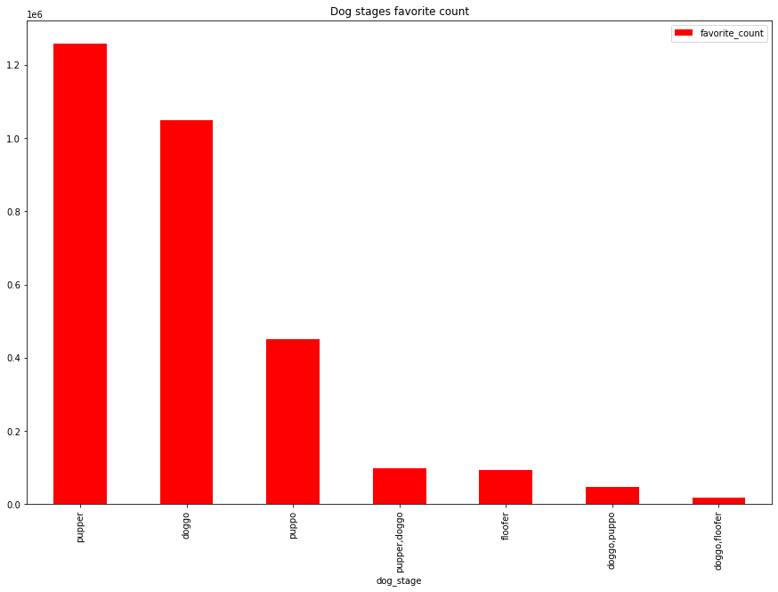

**Dog Names Tweet Engagement**

Another interesting insight has to do with the tweets engagements as it relates to the dog names. I was able to establish the dog name (Tucker) as the dog with the highest count or occurence in the datasets with a value of 10.

Insight as it relates to the favourite counts of the dogs names show that the dog name Bo had a favourite count of 136148 while insight that relates to retweet count showed that the dog(Stephan) had the highest retweet count of 56625.

**Dog Breed Tweet Engagement**

The dog breed(Golden Retriever) happens to be the most sought after has it had the highest form of engagement in terms of the favourite tweets and retweets. The Labrador retriever also followed the Golden Retriever as the dog breed with the most retweet counts and favourite tweet count. The Japanese Spaniel came bottom of the list with the lowest retweets and favorites counts.

Reference

https://twitter.com/dog_rates/status/1433110983120093191/photo/1